# Course Project - 07 Regression

Joe Nguyen

19 November 2015

# Executive Summary

This report aims to explore two questions:

1. Is an automatic or manual transmission better for miles per gallon (MPG)?
2. Quantify the MPG difference between automatic and manual transmissions

## Explore `mtcars` dataset

```r
data("mtcars")
head(mtcars,2)
```

```
##               mpg cyl disp  hp drat    wt  qsec vs am gear carb
## Mazda RX4      21   6  160 110  3.9 2.620 16.46  0  1    4    4
## Mazda RX4 Wag  21   6  160 110  3.9 2.875 17.02  0  1    4    4
```

```r
tail(mtcars,2)
```

```
##                mpg cyl disp  hp drat   wt qsec vs am gear carb
## Maserati Bora 15.0   8  301 335 3.54 3.57 14.6  0  1    5    8
## Volvo 142E    21.4   4  121 109 4.11 2.78 18.6  1  1    4    2
```

Variable `am` is transmission type (0 = automatic, 1 = manual) (from R documentation `?mtcars`). A distribution plot of `am` for MPG is shown in Fig. 1.

## Model Selection and Fitting

We treat `am` as a factor variable with two levels and perform regression with the linear model:

$Y_i = \beta_0 + X_{i1} \beta_1 + \epsilon_i$

Using least squares, $\hat{\beta}_0$ is the mean estimate for “automatic” and $\hat{\beta}_0 + \hat{\beta}_1$ is the mean estimate for “manual”. The coefficient $\beta_1$ is the change in the mean of “manual” from “automatic”.

```r
mtcars$am <- factor(mtcars$am, labels = c("Automatic", "Manual"))
mpgMn <- with(mtcars, aggregate(mpg, by = list(am), mean))

modLm <- lm(mpg ~ am, data = mtcars)
summary(modLm)
```

```
##
## Call:
## lm(formula = mpg ~ am, data = mtcars)
##
## Residuals:
##     Min      1Q  Median      3Q     Max
## -9.3923 -3.0923 -0.2974  3.2439  9.5077
##
## Coefficients:
##             Estimate Std. Error t value Pr(>|t|)
## (Intercept)   17.147      1.125  15.247 1.13e-15 ***
## amManual       7.245      1.764   4.106 0.000285 ***
## ---
## Signif. codes:  0 '***' 0.001 '**' 0.01 '*' 0.05 '.' 0.1 ' ' 1
##
## Residual standard error: 4.902 on 30 degrees of freedom
## Multiple R-squared:  0.3598, Adjusted R-squared:  0.3385
## F-statistic: 16.86 on 1 and 30 DF,  p-value: 0.000285
```

The estimated means from the linear model for “automatic” ($\hat{\beta}_0 = 17.147$) and “manual” ($\hat{\beta}_0 + \hat{\beta}_1 = 17.147 + 7.245 = 24.392$) correspond to the means (points) in Fig. 1.

### Model Selection

First, we propose that **no other regressors** are required in our linear model to answer the question *Is an automatic or manual transmission better for MPG?* The regressor `am` directly captures the affect of transmission type on MPG.

However, we investigate whether addition regressors have a strong influence on explaining MPG. The goal of model building is to balance bias and variance inflation. Note,

1. if we include unrelated regressors, the standard errors of all regressors increase,
2. if we include addition regressors that are correlated with current regressors, the variance increases.

We can evaluate the variance inflation factor (VIF) of each regressor. As a general rule,

| VIF | Status of Regressors |
| --- | --- |
| VIF = 1 | Uncorrelated (and zero inflation) |
| 1 < VIF < 5 | Moderately correlated |
| VIF > 5 to 10 | Highly correlated |

```r
library(car)
modFull <- lm(mpg ~ ., data = mtcars)
vif(modFull)
```

```
##       cyl      disp        hp      drat        wt      qsec        vs
## 15.373833 21.620241  9.832037  3.374620 15.164887  7.527958  4.965873
##        am      gear      carb
##  4.648487  5.357452  7.908747
```

We would choose `disp` as an additional regressor because it is highly correlated with the other regressors, suggesting `disp` can well-explain MPG in this dataset. This correlation between `disp` and `am` is evident in Fig. 2 where “manual” cars tend to have low displacement (`disp`) and “automatic” cars have high displacement.

We can further use analysis of variance (ANOVA) and examine the F-test p-value for significance by including `disp` with `am`.

```r
mod_1 <- update(modLm, mpg ~ am + disp)
features <- names(subset(mtcars, select = -c(mpg, am, disp)))
form <- as.formula(paste("mpg ~ am + disp + ", paste(features, collapse = "+")))
mod_2 <- update(modLm, form)

anova(modLm, mod_1, mod_2)
```

```
## Analysis of Variance Table
##
## Model 1: mpg ~ am
## Model 2: mpg ~ am + disp
## Model 3: mpg ~ am + disp + cyl + hp + drat + wt + qsec + vs + gear + carb
##   Res.Df    RSS Df Sum of Sq       F    Pr(>F)
## 1     30 720.90
## 2     29 300.28  1    420.62 59.8865 1.397e-07 ***
## 3     21 147.49  8    152.79  2.7192   0.03157 *
## ---
## Signif. codes:  0 '***' 0.001 '**' 0.01 '*' 0.05 '.' 0.1 ' ' 1
```

**Total sum of squares = Explained sum of squares + Residual sum of squares (RSS)**

```r
(420.62 - 152.79) / 420.62 * 100
```

```
## [1] 63.67505
```

## Diagnostics

We investigate the quality of the original model (`mpg ~ am`) fit by examining residual variation. As seen in Fig. 3, there is no systematic patterns or outlying data points.

We also examine the data points in the dataset to observe whether or not individual data points have high influence (e.g. leverage) on the model. Diagnostics include `dffits`, `dfbetas`, `cooks.distance` and `hatvalues`. The results suggest all data points well-represent the model, and results are shown in the appendix.

## Regression Inference

```r
summary(modLm)
```

```
##
## Call:
## lm(formula = mpg ~ am, data = mtcars)
##
## Residuals:
##     Min      1Q  Median      3Q     Max
## -9.3923 -3.0923 -0.2974  3.2439  9.5077
##
## Coefficients:
##             Estimate Std. Error t value Pr(>|t|)
## (Intercept)   17.147      1.125  15.247 1.13e-15 ***
## amManual       7.245      1.764   4.106 0.000285 ***
## ---
## Signif. codes:  0 '***' 0.001 '**' 0.01 '*' 0.05 '.' 0.1 ' ' 1
##
## Residual standard error: 4.902 on 30 degrees of freedom
## Multiple R-squared:  0.3598, Adjusted R-squared:  0.3385
## F-statistic: 16.86 on 1 and 30 DF,  p-value: 0.000285
```

### Confidence and Prediction Intervals

The 95% confidence intervals for the MPG mean of “automatic” and “manual” are shown below.

|  | Mean | Lower | Upper |
| --- | --- | --- | --- |
| Automatic | 17.15 | 14.85 | 19.44 |
| Manual | 24.39 | 21.62 | 27.17 |

The 95% prediction intervals are similarly shown below; they are wider than the confidence intervals.

|  | Mean | Lower | Upper |
| --- | --- | --- | --- |
| Automatic | 17.15 | 6.88 | 27.42 |
| Manual | 24.39 | 14.00 | 34.78 |

```r
modLmMn <- lm(mpg ~ am - 1, data = mtcars)
modCoef <- summary(modLmMn)$coef

# # vectors stored as columns by default
# modCoef[,1] + qt(0.975, df = modLmMn$df) * modCoef[,2] %*% t(c(-1,1))

predict(modLm, newdata = data.frame(am = as.factor(c("Automatic", "Manual"))), interval = "confidence")
```

```
##        fit      lwr      upr
## 1 17.14737 14.85062 19.44411
## 2 24.39231 21.61568 27.16894
```

```r
predict(modLm, newdata = data.frame(am = as.factor(c("Automatic", "Manual"))), interval = "prediction")
```

```
##        fit       lwr      upr
## 1 17.14737  6.876013 27.41872
## 2 24.39231 14.003113 34.78150
```

# Appendix

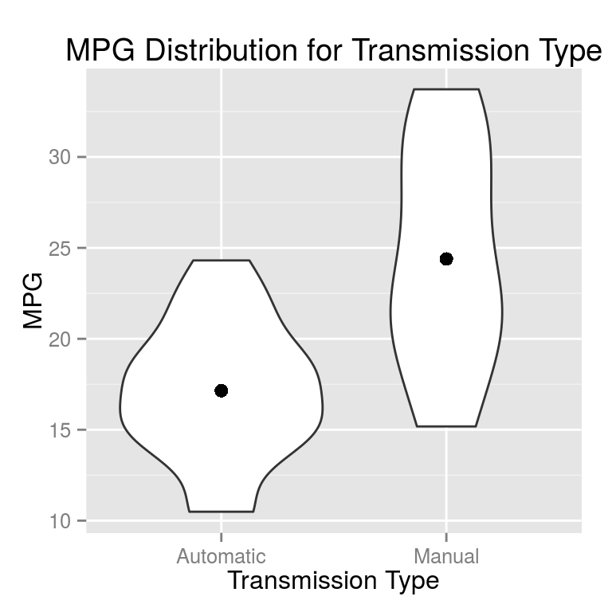

```r
require(ggplot2)
ggplot(aes(am, mpg), data = mtcars) +
    geom_violin() +
    geom_point(aes(x = levels(am), y = mpgMn$x), size = 3) +
    ggtitle("MPG Distribution for Transmission Type") +
    xlab("Transmission Type") + ylab("MPG")
```

**Figure 1** MPG distribution for transmission type (“automatic” or “manual”).

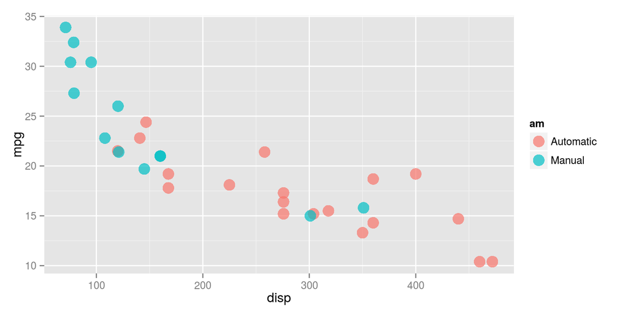

```r
ggplot(aes(disp, mpg, colour = am), data = mtcars) +
    geom_point(size = 5, alpha = 0.7)
```

**Figure 2** Engine displacement (`disp`) is correlated with transmission type (`am`) and can well-explain the outcome MPG. “Manual” cars tend to have lower displacement and higher MPG, while “automatic” cars tend to have higher displacement and lower MPG.

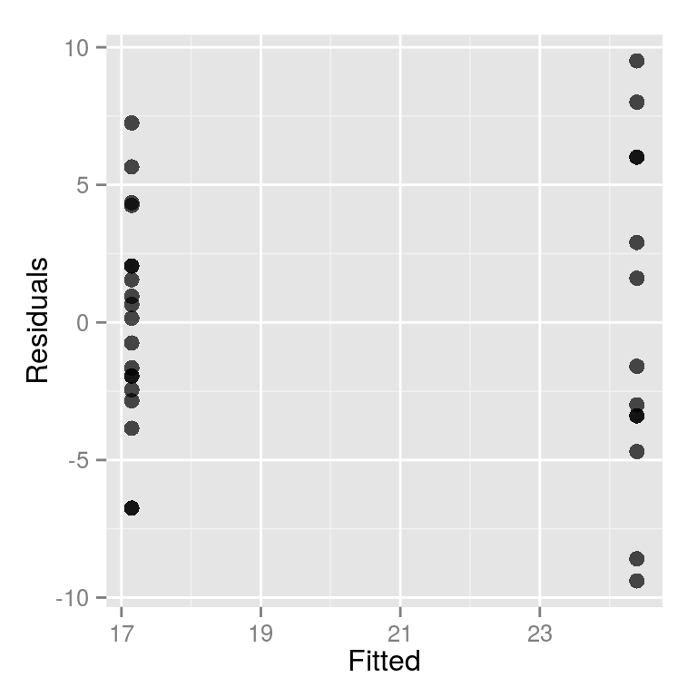

```r
par(mfrow = c(2,2))
modLmDf <- data.frame(Fitted = predict(modLm),
                      Residuals = resid(modLm))
ggplot(data = modLmDf, aes(x = Fitted, y = Residuals)) +
    geom_point(size = 3, alpha = 0.7)
```

**Figure 3** Residuals plot for predicted values according to the linear model `lm(mpg ~ am)`.

```r
# Diagnostics when ith point is deleted in fitting the model:
# Change in outcome
dffits(modLm)
```

```
##           Mazda RX4       Mazda RX4 Wag          Datsun 710
##         -0.20622259         -0.20622259         -0.09614105
##      Hornet 4 Drive   Hornet Sportabout             Valiant
##          0.20933999          0.07554454          0.04629995
##          Duster 360           Merc 240D            Merc 230
##         -0.13912453          0.36666217          0.28120441
##            Merc 280           Merc 280C          Merc 450SE
##          0.10000497          0.03170811         -0.03631443
##          Merc 450SL         Merc 450SLC  Cadillac Fleetwood
##          0.00741342         -0.09484710         -0.33922020
## Lincoln Continental   Chrysler Imperial            Fiat 128
##         -0.33922020         -0.11939303          0.50764834
##         Honda Civic      Toyota Corolla       Toyota Corona
##          0.37228001          0.61635638          0.21440138
##    Dodge Challenger         AMC Javelin          Camaro Z28
##         -0.08017189         -0.09484710         -0.18892470
##    Pontiac Firebird           Fiat X1-9       Porsche 914-2
##          0.10000497          0.17635103          0.09707356
##        Lotus Europa      Ford Pantera L        Ferrari Dino
##          0.37228001         -0.54915951         -0.28757147
##       Maserati Bora          Volvo 142E
##         -0.60772507         -0.18155193
```

```r
# Change in individual coefficients
dfbetas(modLm)
```

```
##                       (Intercept)     amManual
## Mazda RX4            0.000000e+00 -0.158905177
## Mazda RX4 Wag        4.500243e-16 -0.158905177
## Datsun 710           0.000000e+00 -0.074081658
## Hornet 4 Drive       2.093400e-01 -0.133428588
## Hornet Sportabout    7.554454e-02 -0.048150382
## Valiant              4.629995e-02 -0.029510543
## Duster 360          -1.391245e-01  0.088674834
## Merc 240D            3.666622e-01 -0.233702195
## Merc 230             2.812044e-01 -0.179233345
## Merc 280             1.000050e-01 -0.063740913
## Merc 280C            3.170811e-02 -0.020210034
## Merc 450SE          -3.631443e-02  0.023145998
## Merc 450SL           7.413420e-03 -0.004725147
## Merc 450SLC         -9.484710e-02  0.060453400
## Cadillac Fleetwood  -3.392202e-01  0.216211303
## Lincoln Continental -3.392202e-01  0.216211303
## Chrysler Imperial   -1.193930e-01  0.076098423
## Fiat 128            -1.083000e-16  0.391169319
## Honda Civic         -3.528691e-17  0.286861013
## Toyota Corolla      -7.383094e-17  0.474934490
## Toyota Corona        2.144014e-01 -0.136654605
## Dodge Challenger    -8.017189e-02  0.051099755
## AMC Javelin         -9.484710e-02  0.060453400
## Camaro Z28          -1.889247e-01  0.120416343
## Pontiac Firebird     1.000050e-01 -0.063740913
## Fiat X1-9            3.453672e-17  0.135887592
## Porsche 914-2       -8.595866e-18  0.074800200
## Lotus Europa        -7.057382e-17  0.286861013
## Ford Pantera L      -1.091846e-16 -0.423155825
## Ferrari Dino         0.000000e+00 -0.221588703
## Maserati Bora       -7.369134e-17 -0.468283618
## Volvo 142E           1.727493e-17 -0.139895155
```

```r
# Overall change in coefficients
cooks.distance(modLm)
```

```
##           Mazda RX4       Mazda RX4 Wag          Datsun 710
##        2.161671e-02        2.161671e-02        4.762699e-03
##      Hornet 4 Drive   Hornet Sportabout             Valiant
##        2.206695e-02        2.941465e-03        1.107329e-03
##          Duster 360           Merc 240D            Merc 230
##        9.892685e-03        6.418272e-02        3.898776e-02
##            Merc 280           Merc 280C          Merc 450SE
##        5.141015e-03        5.197124e-04        6.815479e-04
##          Merc 450SL         Merc 450SLC  Cadillac Fleetwood
##        2.842599e-05        4.627252e-03        5.555149e-02
## Lincoln Continental   Chrysler Imperial            Fiat 128
##        5.555149e-02        7.308455e-03        1.204520e-01
##         Honda Civic      Toyota Corolla       Toyota Corona
##        6.779763e-02        1.698046e-01        2.311696e-02
##    Dodge Challenger         AMC Javelin          Camaro Z28
##        3.311375e-03        4.627252e-03        1.806153e-02
##    Pontiac Firebird           Fiat X1-9       Porsche 914-2
##        5.141015e-03        1.588167e-02        4.855176e-03
##        Lotus Europa      Ford Pantera L        Ferrari Dino
##        6.779763e-02        1.386816e-01        4.135920e-02
##       Maserati Bora          Volvo 142E
##        1.657081e-01        1.681944e-02
```

```r
# Leverage
hatvalues(modLm)
```

```
##           Mazda RX4       Mazda RX4 Wag          Datsun 710
##          0.07692308          0.07692308          0.07692308
##      Hornet 4 Drive   Hornet Sportabout             Valiant
##          0.05263158          0.05263158          0.05263158
##          Duster 360           Merc 240D            Merc 230
##          0.05263158          0.05263158          0.05263158
##            Merc 280           Merc 280C          Merc 450SE
##          0.05263158          0.05263158          0.05263158
##          Merc 450SL         Merc 450SLC  Cadillac Fleetwood
##          0.05263158          0.05263158          0.05263158
## Lincoln Continental   Chrysler Imperial            Fiat 128
##          0.05263158          0.05263158          0.07692308
##         Honda Civic      Toyota Corolla       Toyota Corona
##          0.07692308          0.07692308          0.05263158
##    Dodge Challenger         AMC Javelin          Camaro Z28
##          0.05263158          0.05263158          0.05263158
##    Pontiac Firebird           Fiat X1-9       Porsche 914-2
##          0.05263158          0.07692308          0.07692308
##        Lotus Europa      Ford Pantera L        Ferrari Dino
##          0.07692308          0.07692308          0.07692308
##       Maserati Bora          Volvo 142E
##          0.07692308          0.07692308
```